# CSCK507 End of Module: Sequence-to-Sequence WikiQA Corpus Generative Chatbot

1. Introduction
2. Data Exploration & Analysis
3. Data Preparation
4. Create Vocabulary
5. Feature Extraction
6. Seq2Seq Model Development
7. Model Evaluation
8. Chatbot Implementation and Manual Testing

## Introduction

Within neural network architectures, the Sequence-to-Sequence network (often abbreviated as seq2seq or Encoder-Decoder network) emerges as a formidable model tailored for handling sequential data. Comprising two distinct Recurrent Neural Networks (RNNs) — the encoder and the decoder — this innovative framework revolutionizes the treatment of input-output relationships. Notably, these models have demonstrated their effectiveness in addressing intricate many-to-many tasks, exemplified in domains such as Machine Translation and Question Answering.

The primary objective of this collaborative project is to implement a seq-2-seq model for a generative chatbot, delving into both attention and non-attention mechanisms with leveraged datasets from the WikiQA Corpus, providing a robust foundation for the training and evaluation of these models.

**This task involves, but is not limited to:**

a. An implement a seq-2-seq model without attention.

b. An implement a seq-2-seq model with attention, with the flexibility to choose between Bahdanau or Luong attention mechanisms.

This Jupyter Notebook was collaboratively prepared by:

- Minh-Dat Andy Ho Huu
- Miguel Ángel López Lago
- Mariam Mustafah Alkhatib
- Wing Kit Matthew Leung
- Mikita Kalamiyets

### Import Dependencies

```python
# Standard library imports
import itertools
import logging
import os
import re
import unicodedata
import urllib.request
from collections import defaultdict
from typing import List, Optional, Set, Tuple
from zipfile import ZipFile

# Related third party imports
import gensim
import matplotlib.pyplot as plt
import nltk
import numpy as np
import pandas as pd
import seaborn as sns
import spacy
import tensorflow as tf
import torch
from gensim.models import Word2Vec
from nltk.probability import FreqDist
from nltk.tokenize import word_tokenize
from nltk.translate.bleu_score import sentence_bleu, SmoothingFunction
from sklearn.model_selection import train_test_split
from tensorflow.keras import regularizers
from torch.utils.data import Dataset, DataLoader
from wordcloud import WordCloud

# Download NLTK data
nltk.download('punkt')

# Warnings configuration
import warnings
```

```
WARNING:tensorflow:From c:\Users\migue\anaconda3\lib\site-packages\keras\src\losses.py:2976: The name tf.losses.sparse_softmax_cross_entropy is deprecated. Please use tf.compat.v1.losses.sparse_softmax_cross_entropy instead.
```

Here we will also define a constant to decide whether to use the GPU (with CUDA specifically) or the CPU. If you don't have a GPU, set this to `False`. Later when we create tensors, this variable will be used to decide whether we keep them on CPU or move them to GPU.

```python
USE_CUDA = True
```

```python
warnings.filterwarnings(action='ignore',category=DeprecationWarning)
warnings.filterwarnings(action='ignore',category=FutureWarning)
```

### Download WikiQA Zip File

The Corpus can be downloaded here: [WikiQACorpus](https://www.microsoft.com/en-us/download/confirmation.aspx?id=52419)

```python
logging.basicConfig(level=logging.INFO)
logger = logging.getLogger(__name__)
```

```python
def download_file(url, destination):
    try:
        urllib.request.urlretrieve(url, destination)
        logger.info(f'Downloaded file from {url} to {destination}')
    except Exception as e:
        logger.error(f'Error downloading file: {e}')

def extract_zip(zip_path, extract_path):
    try:
        with ZipFile(zip_path, 'r') as zip_ref:
            zip_ref.extractall(extract_path)
        logger.info(f'Extracted {zip_path} to {extract_path}')
    except Exception as e:
        logger.error(f'Error extracting zip file: {e}')

def create_directory(directory):
    if not os.path.exists(directory):
        os.makedirs(directory)
        logger.info(f'Created directory: {directory}')

CORPUS_NAME = 'WikiQACorpus'
CORPUS_URL = 'https://www.microsoft.com/en-us/download/confirmation.aspx?id=52419'
CORPUS_DIR = os.path.join(CORPUS_NAME)
DATASET_ZIP = os.path.join(CORPUS_DIR, 'WikiQACorpus.zip')

# Check if dataset directory already exists
if os.path.exists(CORPUS_DIR):
    print(f'{CORPUS_NAME} already exists')
else:
    if os.path.exists(DATASET_ZIP):
        create_directory(CORPUS_DIR)
        extract_zip(DATASET_ZIP, CORPUS_DIR)
        os.remove(DATASET_ZIP)
        print(f'{CORPUS_NAME} extracted')
    else:
        print(f'To obtain the "{CORPUS_NAME}" dataset, please follow these steps:')
        print(f'1. Manually download the WikiQA dataset from: {CORPUS_URL}')
        print(f'2. Place the downloaded "WikiQACorpus.zip" file in the "{CORPUS_DIR}" folder.')
        print(f'3. Rerun this script after placing the corpus in the correct location.')
```

```
WikiQACorpus already exists
```

### Load Dataset into DataFrame

```python
def load_wikiqa_df(file_path):
    # Define column names for the DataFrame
    column_names = ['Question', 'Answer', 'Label']

    df = pd.read_csv(file_path, delimiter='\t', encoding='utf-8', header=None, names=column_names)
    return df
```

```python
# Load WikiQA datasets into DataFrames
train_df = load_wikiqa_df(os.path.join(CORPUS_DIR, 'WikiQA-train.txt'))
dev_df = load_wikiqa_df(os.path.join(CORPUS_DIR, 'WikiQA-dev.txt'))
test_df = load_wikiqa_df(os.path.join(CORPUS_DIR, 'WikiQA-test.txt'))
```

## Data Exploration & Analysis

```python
# Combine train and dev dataframes. Split further down in 80/20 proportion.
train_df = pd.concat([train_df, dev_df])
train_df.sample(10).tail(10)
```

|  | Question | Answer | Label |
| --- | --- | --- | --- |
| 6275 | how many feet in an acre | It is still used , to some extent , in Canada . | 0 |
| 3740 | How many Gray Wolves are in the world | The gray wolf is one of the world 's most well... | 0 |
| 14660 | what is the truth in negotiations act act | The agreement aims to establish an internation... | 0 |
| 1688 | when did scott pilgrim come out | Wright became attached to the project and film... | 0 |
| 12370 | where do flesh eating bacteria live | Some published case reports have implied a pos... | 0 |
| 11293 | what is a good leg press | The leg press is a weight training exercise in... | 0 |
| 18416 | what is the name of mountains along california | The Coast Ranges of California span from Humbo... | 0 |
| 19458 | What is the full name of the first lady and th... | Because this position is traditionally filled ... | 0 |
| 8025 | who build the san juan capistrano mission | More than 2,000 former inhabitants ( mostly Ju... | 0 |
| 9812 | what are new covenant church | Generally , Christians believe that the New Co... | 0 |

```python
train_df.info()
print("The table dimensions are:",train_df.shape)
```

```
<class 'pandas.core.frame.DataFrame'>
Int64Index: 23093 entries, 0 to 2732
Data columns (total 3 columns):
 #   Column    Non-Null Count  Dtype
---  ------    --------------  -----
 0   Question  23093 non-null  object
 1   Answer    23093 non-null  object
 2   Label     23093 non-null  int64
dtypes: int64(1), object(2)
memory usage: 721.7+ KB
The table dimensions are: (23093, 3)
```

```python
# Check for missing values in train, dev, and test datasets
missing_values_train = train_df.isnull().sum()
missing_values_test = test_df.isnull().sum()

print("Missing Values train:", missing_values_train)
print("Missing Values test:", missing_values_test)

# Check for duplicate entries in train, dev, and test datasets
duplicate_entries_train = train_df.duplicated().sum()
duplicate_entries_test = test_df.duplicated().sum()

print("\nDuplicate Entries train:", duplicate_entries_train)
print("Duplicate Entries test:", duplicate_entries_test)

# Check for inconsistent formatting in Questions and Answers for train, dev, and test datasets
inconsistent_formatting_question_train = train_df['Question'].apply(lambda x: x.strip() != x).sum()
inconsistent_formatting_answer_train = train_df['Answer'].apply(lambda x: x.strip() != x).sum()

inconsistent_formatting_question_test = test_df['Question'].apply(lambda x: x.strip() != x).sum()
inconsistent_formatting_answer_test = test_df['Answer'].apply(lambda x: x.strip() != x).sum()

print("\nInconsistent Formatting in Questions (Train):", inconsistent_formatting_question_train)
print("Inconsistent Formatting in Answers (Train):", inconsistent_formatting_answer_train)
print("Inconsistent Formatting in Questions (Test):", inconsistent_formatting_question_test)
print("Inconsistent Formatting in Answers (Test):", inconsistent_formatting_answer_test)
```

```
Missing Values train: Question    0
Answer      0
Label       0
dtype: int64
Missing Values test: Question    0
Answer      0
Label       0
dtype: int64

Duplicate Entries train: 3
Duplicate Entries test: 5

Inconsistent Formatting in Questions (Train): 0
Inconsistent Formatting in Answers (Train): 0
Inconsistent Formatting in Questions (Test): 0
Inconsistent Formatting in Answers (Test): 0
```

```python
# Check for duplicate entries in train dataset and print them
duplicate_entries_train = train_df[train_df.duplicated(keep=False)]
print("\nDuplicate Entries in train:")
print(duplicate_entries_train.to_string(index=False))

# Check for duplicate entries in test dataset and print them
duplicate_entries_test = test_df[test_df.duplicated(keep=False)]
print("\nDuplicate Entries in test:")
print(duplicate_entries_test.to_string(index=False))
```

```
Duplicate Entries in train:
                          Question                           Answer  Label
           what are sanuks made of                            right      0
           what are sanuks made of                            right      0
who starred in the drama emergency                      Emergency !      0
who starred in the drama emergency                      Emergency !      0
   what do you want from me quotes `` What Do You Want from Me ? ''      0
   what do you want from me quotes `` What Do You Want from Me ? ''      0

Duplicate Entries in test:
                                       Question                       Answer  Label
what experiments are being performed on the iss             MISSE PEC closed      0
what experiments are being performed on the iss             MISSE PEC closed      0
what did deputies in the old western times do ?                        right      0
what did deputies in the old western times do ?                        right      0
what did deputies in the old western times do ?                        right      0
what did deputies in the old western times do ?                        right      0
                          what is a CMM machine Coordinate Measuring Machine      0
                          what is a CMM machine Coordinate Measuring Machine      0
```

```python
# Remove duplicate entries from the train, dev, and test datasets
train_df = train_df.drop_duplicates()
test_df = test_df.drop_duplicates()

# Confirm they are removed
duplicate_entries_train_after = train_df.duplicated().sum()
duplicate_entries_test_after = test_df.duplicated().sum()

print("\nDuplicate Entries in train after removal:", duplicate_entries_train_after)
print("Duplicate Entries in test after removal:", duplicate_entries_test_after)
```

```
Duplicate Entries in train after removal: 0
Duplicate Entries in test after removal: 0
```

### Word Count Distribution Analysis

Word count distribution analysis serves as a foundational step in preparing the data for subsequent model training. It informs decisions related to model selection, sequence padding, and ensures compatibility between the chosen model and the characteristics of the dataset, including key considerations such as:

**Model Selection:** Different NLP models may have preferences for sequences of certain lengths. Analysing the word count distribution assists in selecting or designing a model that aligns with the characteristics of the dataset.

**Sequence Padding:** Many NLP models require fixed-length input sequences. Understanding the distribution helps determine an appropriate length for padding, striking a balance between capturing essential information and efficient computational processing.

"**Insight into Data Characteristics:** Examining the distribution provides insights into the diversity of sentence lengths within the dataset. This understanding is valuable for tailoring preprocessing steps and optimizing model training.

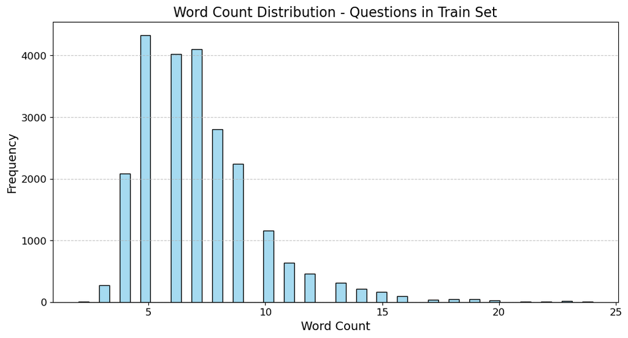

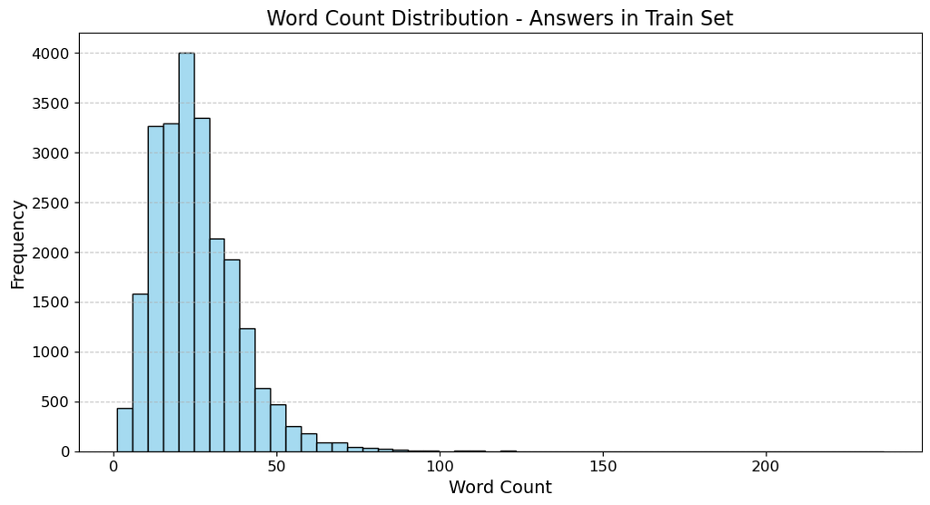

```python
# Function to calculate and plot word count distribution
def plot_word_count_distribution(dataframe, column, title):
    word_counts = dataframe[column].apply(lambda x: len(str(x).split()))

    plt.figure(figsize=(12, 6))
    sns.histplot(word_counts, bins=50, kde=False, color='skyblue', edgecolor='black')
    plt.title(title, fontsize=16)
    plt.xlabel('Word Count', fontsize=14)
    plt.ylabel('Frequency', fontsize=14)
    plt.xticks(fontsize=12)
    plt.yticks(fontsize=12)
    plt.grid(axis='y', linestyle='--', alpha=0.7)

    plt.show()

# Plot word count distribution for both questions and answers
plot_word_count_distribution(train_df, 'Question', 'Word Count Distribution - Questions in Train Set')
plot_word_count_distribution(train_df, 'Answer', 'Word Count Distribution - Answers in Train Set')
```

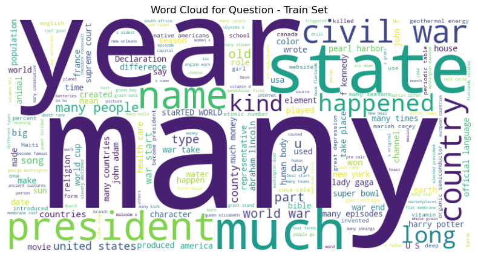

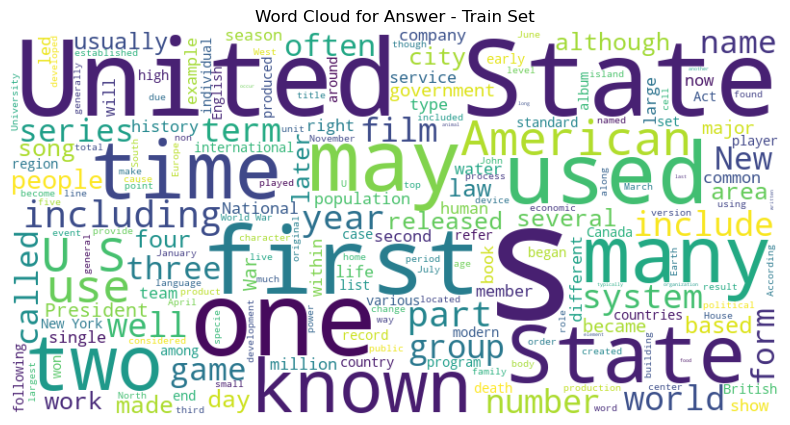

```python
# Function to generate and display word clouds
def generate_word_cloud(dataframe, column, title):
    text = ' '.join(dataframe[column].astype(str).tolist())

    wordcloud = WordCloud(width=800, height=400, random_state=42, background_color='white').generate(text)

    plt.figure(figsize=(10, 5))
    plt.imshow(wordcloud, interpolation='bilinear')
    plt.axis('off')
    plt.title(title)
    plt.show()

# Generate word clouds for queries and responses in train_df
generate_word_cloud(train_df, 'Question', 'Word Cloud for Question - Train Set')
generate_word_cloud(train_df, 'Answer', 'Word Cloud for Answer - Train Set')
```

## Data Preparation

### Initialise SpaCy Model

```python
# Download spaCy model if not available
try:
    spacy.load('en_core_web_sm')
except OSError:
    print('To use spaCy with GPU support, run: python -m spacy download en_core_web_sm')

nlp = spacy.load("en_core_web_sm", disable=['parser', 'ner'])
```

## Create Vocabulary

This segment establishes a vocabulary (Voc) class for a language model, initializing it with special tokens: PAD (padding), SOS (start of sentence), EOS (end of sentence), and UNK (unknown word). The Voc class functions to map words to indexes and vice versa, keeping track of word frequencies. It includes a method to trim the vocabulary by removing infrequent words. Additionally, there are functions to normalize text using ASCII conversion and SpaCy tokenization, and a function to create a corpus from a DataFrame, which is instrumental in processing and preparing data for the language model.

```python
# Default word tokens
PAD_TOKEN = 0  # Used for padding short sentences
SOS_TOKEN = 1  # Start-of-sentence token
EOS_TOKEN = 2  # End-of-sentence token
UNK_TOKEN = 3  # unknown word token


class Voc:
    def __init__(self, name):
        self.name = name
        self.trimmed = False
        self.word2index = {"PAD":PAD_TOKEN, "SOS":SOS_TOKEN , "EOS":EOS_TOKEN , "UNK":UNK_TOKEN }
        self.word2count = {}
        self.index2word = {PAD_TOKEN: "PAD", SOS_TOKEN: "SOS", EOS_TOKEN: "EOS", UNK_TOKEN: "UNK"}
        self.num_words = 4  # Count SOS, EOS, PAD, UNK

    def addSentence(self, sentence):
        for word in sentence.split(' '):
            self.addWord(word)

    def addWord(self, word):
        if word not in self.word2index:
            self.word2index[word] = self.num_words
            self.word2count[word] = 1
            self.index2word[self.num_words] = word
            self.num_words += 1
        else:
            self.word2count[word] += 1

    # Remove words below a certain count threshold
    def trim(self, min_count):
        if self.trimmed:
            return
        self.trimmed = True

        keep_words = []

        for k, v in self.word2count.items():
            if v >= min_count:
                keep_words.append(k)

        print('keep_words {} / {} = {:.4f}'.format(
            len(keep_words), len(self.word2index), len(keep_words) / len(self.word2index)
        ))

        # Reinitialize dictionaries
        self.word2index = {}
        self.word2count = {}
        self.index2word = {PAD_TOKEN: "PAD", SOS_TOKEN: "SOS", EOS_TOKEN: "EOS"}
        self.num_words = 3 # Count default tokens

        for word in keep_words:
            self.addWord(word)

voc = Voc(train_df)

def unicode_to_ascii(input_str):
    """
    Converts a Unicode string to plain ASCII by removing diacritics.
    """
    normalized_str = unicodedata.normalize('NFD', input_str)
    ascii_str = ''.join(char for char in normalized_str if unicodedata.category(char) != 'Mn')
    return ascii_str

def normalize_string_spacy(input_str):
    """
    Tokenizes and normalizes a string using SpaCy.
    """
    # Convert to plain ASCII
    ascii_str = unicode_to_ascii(input_str)

    # Tokenize and normalize using SpaCy
    doc = nlp(ascii_str)
    tokens = [token.text for token in doc]

    # Join the tokens into a normalized string
    normalized_str = ' '.join(tokens)

    return normalized_str

# Function to create a corpus from DataFrame
def create_corpus_from_df(df_list):
    corpus = []
    for df in df_list:
        for text in pd.concat([df['Question'], df['Answer']]):
            normalized_text = normalize_string_spacy(text)
            tokenized_text = [word.lower() for word in word_tokenize(normalized_text)]
            corpus.append(tokenized_text)
    return corpus
```

### Accelerating Convergence in NLP Models with Word Count Constraints

The strategic selection of the `MAX_LENGTH` parameters during preparation is vital for a sequence-to-sequence (seq2seq) model.

- **MAX_LENGTH:** Determines the maximum allowed length for input sentences, ensuring uniformity, efficient batch processing, and compatibility with fixed-size input models.

**This practice offers several benefits:**

1. Reduced Dimensionality and Efficiency: Setting a maximum word count minimizes feature space, enhancing computational efficiency, especially in models like RNNs and transformers.
2. Handling Varied Text Lengths and Normalization: Enforcing a maximum word count normalizes input sequences, simplifying learning and ensuring consistent data preparation.
3. Dealing with Outliers: Limits on word count effectively handle outliers, such as excessively long sentences, preventing them from dominating the learning process.
4. Memory Efficiency and GPU Usage: Shorter sequences from a maximum word count enhance GPU memory efficiency, crucial for deep learning models with substantial computational needs.
5. Optimizing Tokenization for Efficiency: A maximum word count streamlines tokenization, contributing to faster preprocessing and overall model training speed.

```python
MAX_LENGTH = 40

# Read query/response pairs and return a voc object
def read_vocs(train_df, CORPUS_NAME):
    print("Reading lines...")
    # Extract pairs from the DataFrame and normalize
    pairs = [[normalize_string_spacy(row['Question']), normalize_string_spacy(row['Answer'])] for _, row in train_df.iterrows()]
    voc = Voc(CORPUS_NAME)
    return voc, pairs

# Returns True if both sentences in a pair 'p' are under the MAX_LENGTH threshold
def filter_pair(p):
    return len(p[0].split(' ')) < MAX_LENGTH and len(p[1].split(' ')) < MAX_LENGTH

# Filter pairs using filterPair condition
def filter_pairs(pairs):
    return [pair for pair in pairs if filter_pair(pair)]
```

### Load data and create corpus

We now are ready to prepare the data to train the model. It involves loading and filtering sentence pairs, updating the vocabulary with these sentences, and creating a corpus for training a Word2Vec model. The process includes building an embedding matrix populated with Word2Vec vectors, where words are represented by their corresponding indices in the vocabulary. This setup facilitates the incorporation of semantic information from Word2Vec into the language model, enhancing its ability to understand and generate human-like language.

```python
# Using the functions defined above, return a populated voc object and pairs list
def load_prepare_data(CORPUS_DIR, CORPUS_NAME, df, save_dir):
    voc, pairs = read_vocs(df[df["Label"] == 1], CORPUS_NAME)
    print("Read {!s} sentence pairs".format(len(pairs)))
    pairs = filter_pairs(pairs)
    print("Filtered to {!s} pairs".format(len(pairs)))
    print("Counted words...")
    for pair in pairs:
        voc.addSentence(pair[0])
        voc.addSentence(pair[1])
    print("Counted words:", voc.num_words)
    return voc, pairs

# Load/Assemble voc and pairs
save_dir = os.path.join("data", "save")
voc, pairs = load_prepare_data(CORPUS_DIR, CORPUS_NAME, train_df, save_dir)

# Create a corpus for Word2Vec training
corpus = create_corpus_from_df([train_df])

# Update the vocabulary with the corpus
for sentence in corpus:
    voc.addSentence(' '.join(sentence))  # Join words to form a sentence

# Set vocabulary size and embedding dimensions
VOCAB_SIZE = voc.num_words
EMBEDDING_DIM = 200

# Train Word2Vec model
word2vec_model = gensim.models.Word2Vec(corpus, min_count=1, vector_size=EMBEDDING_DIM, window=5)

# Initialize embedding matrix - use for weights
embedding_matrix = np.zeros((VOCAB_SIZE, EMBEDDING_DIM))

# Populate embedding matrix with Word2Vec vectors
for word, index in voc.word2index.items():
    if word in word2vec_model.wv.key_to_index:
        embedding_matrix[index] = word2vec_model.wv[word]
    else:
        embedding_matrix[index] = np.random.normal(size=(EMBEDDING_DIM,))
```

```
Reading lines...
Read 1180 sentence pairs
Filtered to 904 pairs
Counted words...
Counted words: 6971
```

[output not shown]

## Feature Extraction

In the data preparation stage, we've transformed linguistic data into a vocabulary object and a list of sentence pairs. To make this data compatible with our model, which operates on numerical tensors, we convert words in sentences to their corresponding indices in the vocabulary. This process involves several steps:

Indexing Sentences: Each word in a sentence is replaced with its index from the vocabulary. The indexes_from_sentence function does this, appending an EOS_TOKEN at the end to indicate the end of a sentence.

Padding Sequences: To handle sentences of varying lengths within a batch and ensure uniformity, we apply zero-padding to shorter sentences using the pad_sequence function. This function pads sequences to a specified maximum length, ensuring that all sequences in a batch have the same length.

Input and Output Tensors: The input_var and output_var functions convert sentences into padded tensors. These tensors are then used as inputs and targets for training the model.

Mask Creation: The create_mask function generates a boolean mask to identify actual data points and padding in a sequence. This mask is essential, especially when implementing attention mechanisms in the model, to focus only on meaningful words and ignore padding.

```python
def indexes_from_sentence(voc, sentence):
    """Converts a sentence to a list of indexes."""
    return [voc.word2index.get(word, UNK_TOKEN) for word in sentence.split(' ')] + [EOS_TOKEN]

def pad_sequence(sequence, max_len):
    """Pad or truncate the sequence to a specified max length."""
    if len(sequence) > max_len:
        sequence = sequence[:max_len]
    return np.pad(sequence, (0, max_len - len(sequence)), mode='constant', constant_values=0)

def input_var(sentence, voc):
    """Converts an input sentence to a padded tensor."""
    sentence = sentence.lower()
    indexes = indexes_from_sentence(voc, sentence)
    return torch.tensor(pad_sequence(indexes, MAX_LENGTH), dtype=torch.long)

def output_var(sentence, voc):
    """Converts a target sentence to a padded tensor."""
    sentence = sentence.lower()
    indexes = indexes_from_sentence(voc, sentence)
    return torch.tensor(pad_sequence(indexes, MAX_LENGTH), dtype=torch.long)

def create_mask(seq):
    # Create a boolean mask where False is padding and True is actual data
    mask = tf.cast(tf.math.not_equal(seq, 0), tf.bool)
    # Reshaping for compatibility with attention layer
    return tf.expand_dims(mask, -1)
```

### Training & Validation Dataset Preparation

To prepare the training and validation datasets, we convert sentence pairs into tensors, sort them by input length for efficient processing, and finally split them into training and validation sets. The tensors are then converted to NumPy arrays and wrapped in TensorFlow datasets, batched and shuffled to optimize the learning process during training.

```python
# Prepare the dataset
paired_tensors = [(input_var(pair[0], voc), output_var(pair[1], voc)) for pair in pairs]

# Sort by length of the input sequence
paired_tensors.sort(key=lambda x: len(x[0]), reverse=True)
input_tensor, target_tensor = zip(*paired_tensors)

# Split into training and validation sets
input_tensor_train, input_tensor_val, target_tensor_train, target_tensor_val \
    = train_test_split(input_tensor, target_tensor, test_size=0.2)

#Set batch size
BATCH_SIZE = 64
BUFFER_SIZE = len(input_tensor_train)
STEPS_PER_EPOCH = len(input_tensor_train) // BATCH_SIZE

# Convert PyTorch tensors to NumPy arrays
input_tensor_train_np = [t.numpy() for t in input_tensor_train]
target_tensor_train_np = [t.numpy() for t in target_tensor_train]
input_tensor_val_np = [t.numpy() for t in input_tensor_val]
target_tensor_val_np = [t.numpy() for t in target_tensor_val]

# Create TensorFlow dataset
dataset = tf.data.Dataset.from_tensor_slices((input_tensor_train_np, target_tensor_train_np)).shuffle(BUFFER_SIZE)
dataset = dataset.batch(BATCH_SIZE, drop_remainder=True)

# Convert the validation data into TensorFlow dataset
validation_dataset = tf.data.Dataset.from_tensor_slices((input_tensor_val_np, target_tensor_val_np)).shuffle(BUFFER_SIZE)
validation_dataset = validation_dataset.batch(BATCH_SIZE, drop_remainder=True)
```

```python
# Check our padded tensors actually make sense by printing the prepared tensors,
# and then converting them back to words for a sanity check.
print("input_tensor:", input_tensor_train_np[0])
print("input_converted:", [voc.index2word[i] for i in input_tensor_train_np[50]])
print("Max len?", len(input_tensor_train_np[0])==MAX_LENGTH)

print("\ntarget_tensor:", target_tensor_train_np[0])
print("input_converted:", [voc.index2word[i] for i in target_tensor_train_np[50]])
print("Max len?:", len(input_tensor_train_np[0])==MAX_LENGTH)
```

```
input_tensor: [ 423  389 3870 3871    9    2    0    0    0    0    0    0    0    0
    0    0    0    0    0    0    0    0    0    0    0    0    0    0
    0    0    0    0    0    0    0    0    0    0    0    0]
input_converted: ['what', 'is', 'squash', 'the', 'sport', 'EOS', 'PAD', 'PAD', 'PAD', 'PAD', 'PAD', 'PAD', 'PAD', 'PAD', 'PAD', 'PAD', 'PAD', 'PAD', 'PAD', 'PAD', 'PAD', 'PAD', 'PAD', 'PAD', 'PAD', 'PAD', 'PAD', 'PAD', 'PAD', 'PAD', 'PAD', 'PAD', 'PAD', 'PAD', 'PAD', 'PAD', 'PAD', 'PAD', 'PAD', 'PAD…
Max len? True

target_tensor: [  682   170   389    97  5014  8323 25753   208    15  3873    17    15
  3874   129   682  3875    61    15  3598    61    59   792  2808   227
   273  1014  9840  3876    18     2     0     0     0     0     0     0
     0     0     0     0]
input_converted: ['squash', 'is', 'a', 'racquet', 'sport', 'played', 'by', 'two', '(', 'singles', ')', 'or', 'four', 'players', '(', 'doubles', ')', 'in', 'a', 'four', '-', 'walled', 'court', 'with', 'a', 'small', ',', 'hollow', 'rubber', 'ball', '.', 'EOS', 'PAD', 'PAD', 'PAD', 'PAD', 'PAD', 'PAD',…
Max len?: True
```

## Seq2Seq Model Development

Each model consists of two main components: an Encoder and two variations of Decoders—one with the Bahdanau attention mechanism and one without.

The vocabulary size is derived from the dataset, and the model employs an embedding dimension of 200, with both the Encoder and Decoder units set at 512. A batch size of 64 is used, and the initial learning rate is set at 0.01, adjusted through an exponential decay schedule.

Two types of decoders are employed to compare performance with and without attention mechanisms. The DecoderNoAttention class, a simpler model, processes input sequences through an embedding layer, followed by LSTM layers and a fully connected output layer, without utilizing attention. In contrast, the Decoder class integrates the BahdanauAttention mechanism, which dynamically focuses on different parts of the input sequence, enhancing the model's ability to understand context and dependencies. Both decoders incorporate dropout for regularization and a masking layer to handle padding. These comparisons allow for an evaluation of the impact of attention mechanisms on the model's performance in language processing tasks.

```python
#set model parameters
ENC_UNITS = 512
DEC_UNITS = 512
INITIAL_LEARNING_RATE = 0.01
```

```python
class BahdanauAttention(tf.keras.layers.Layer):
    """
    Bahdanau Attention mechanism layer. Computes the attention weights
    and returns a context vector as a weighted
    sum of encoder outputs, and attention weights.

    Attributes:
        W1: Dense layer for the decoder hidden state.
        W2: Dense layer for the encoder output.
        V: Dense layer to compute the attention scores.
    """

    def __init__(self, units):
        super(BahdanauAttention, self).__init__()
        self.W1 = tf.keras.layers.Dense(units)
        self.W2 = tf.keras.layers.Dense(units)
        self.V = tf.keras.layers.Dense(1)

    def call(self, query, values, mask):
        query_with_time_axis = tf.expand_dims(query, 1)
        scores = self.V(tf.nn.tanh(self.W1(query_with_time_axis) + self.W2(values)))

        if mask is not None:
            # Convert boolean mask to float and apply to scores
            scores -= (1 - tf.cast(mask, tf.float32)) * 1e9

        attention_weights = tf.nn.softmax(scores, axis=1)
        context_vector = attention_weights * values
        context_vector = tf.reduce_sum(context_vector, axis=1)
        return context_vector, attention_weights

class Encoder(tf.keras.Model):
    """
    Encoder for a sequence-to-sequence model, using LSTM.

    Attributes:
        batch_sz: Batch size for the encoder.
        ENC_UNITS: Number of LSTM units.
        embedding: Embedding layer for input sequence.
        dropout: Dropout layer for regularization.
        lstm: LSTM layer.
    """
    def __init__(self, VOCAB_SIZE, EMBEDDING_DIM, ENC_UNITS, batch_sz, dropout_rate=0.5):
        super(Encoder, self).__init__()
        self.batch_sz = batch_sz
        self.ENC_UNITS = ENC_UNITS
        self.embedding = tf.keras.layers.Embedding(VOCAB_SIZE, EMBEDDING_DIM, weights=[embedding_matrix], trainable=True)
        self.dropout = tf.keras.layers.Dropout(dropout_rate)
        self.masking = tf.keras.layers.Masking(mask_value=0.0)
        self.lstm = tf.keras.layers.LSTM(self.ENC_UNITS, return_sequences=True, return_state=True)

    def initialize_hidden_state(self):
        return [tf.zeros((self.batch_sz, self.ENC_UNITS)), tf.zeros((self.batch_sz, self.ENC_UNITS))]

    def call(self, x, hidden):
        x = self.embedding(x)
        x = self.masking(x)
        x = self.dropout(x)
        output, state_h, state_c = self.lstm(x, initial_state=hidden)
        return output, state_h, state_c

class DecoderNoAttention(tf.keras.Model):
    """
    Decoder for sequence-to-sequence model without attention.

    Attributes:
        batch_sz: Batch size for the decoder.
        DEC_UNITS: Number of LSTM units.
        embedding: Embedding layer for input sequence.
        dropout: Dropout layer for regularization.
        lstm: LSTM layer.
        fc: Fully connected layer for output.
    """
    def __init__(self, VOCAB_SIZE, EMBEDDING_DIM, DEC_UNITS, batch_sz, dropout_rate=0.5):
        super(DecoderNoAttention, self).__init__()
        self.batch_sz = batch_sz
        self.DEC_UNITS = DEC_UNITS
        self.embedding = tf.keras.layers.Embedding(VOCAB_SIZE, EMBEDDING_DIM, weights=[embedding_matrix], trainable=True)
        self.dropout = tf.keras.layers.Dropout(dropout_rate)
        self.masking = tf.keras.layers.Masking(mask_value=0.0)
        self.lstm = tf.keras.layers.LSTM(self.DEC_UNITS, return_sequences=True, return_state=True)
        self.fc = tf.keras.layers.Dense(VOCAB_SIZE, activation = 'softmax', kernel_regularizer=regularizers.l2(0.01))

    def call(self, x, hidden):
        x = self.embedding(x)
        x = self.masking(x)
        x = self.dropout(x)
        output, state_h, state_c = self.lstm(x, initial_state=hidden)
        output = self.dropout(output)
        output = tf.reshape(output, (-1, output.shape[2]))
        x = self.fc(output)
        return x, state_h, state_c

class Decoder(tf.keras.Model):
    """
    Decoder with Bahdanau attention for sequence-to-sequence model.

    Attributes:
        batch_sz: Batch size for the decoder.
        DEC_UNITS: Number of LSTM units.
        embedding: Embedding layer for input sequence.
        dropout: Dropout layer for regularization.
        lstm: LSTM layer.
        fc: Fully connected layer for output.
        attention: Bahdanau attention layer.
    """
    def __init__(self, VOCAB_SIZE, EMBEDDING_DIM, DEC_UNITS, batch_sz, dropout_rate=0.5):
        super(Decoder, self).__init__()
        self.batch_sz = batch_sz
        self.DEC_UNITS = DEC_UNITS
        self.embedding = tf.keras.layers.Embedding(VOCAB_SIZE, EMBEDDING_DIM, weights=[embedding_matrix], trainable=True)
        self.dropout = tf.keras.layers.Dropout(dropout_rate)
        self.masking = tf.keras.layers.Masking(mask_value=0.0)
        self.lstm = tf.keras.layers.LSTM(self.DEC_UNITS, return_sequences=True, return_state=True)
        self.fc = tf.keras.layers.Dense(VOCAB_SIZE, activation = 'softmax', kernel_regularizer=regularizers.l2(0.01))
        self.attention = BahdanauAttention(self.DEC_UNITS)

    def call(self, x, hidden, enc_output, mask):
        context_vector, attention_weights = self.attention(hidden[0], enc_output, mask)
        x = self.embedding(x)
        x = self.masking(x)
        x = self.dropout(x)
        x = tf.concat([tf.expand_dims(context_vector, 1), x], axis=-1)
        output, state_h, state_c = self.lstm(x, initial_state=hidden)
        output = self.dropout(output)
        output = tf.reshape(output, (-1, output.shape[2]))
        x = self.fc(output)
        return x, state_h, state_c, attention_weights
```

For training and loss computation, the model uses Sparse Categorical Crossentropy as the loss function and applies gradient clipping to stabilize training. The training function is designed to accommodate both attention and non-attention decoders, running separate training loops for each to facilitate a comparative analysis of their performance. Overall, this architecture aims to explore the impact and efficacy of attention mechanisms in Seq2Seq models, particularly for language-related tasks.

```python
EPOCHS = 30
# Instantiate the encoder and decoder
encoder = Encoder(VOCAB_SIZE, EMBEDDING_DIM, ENC_UNITS, BATCH_SIZE)
# Model with attention
decoder_with_attention = Decoder(VOCAB_SIZE, EMBEDDING_DIM, DEC_UNITS, BATCH_SIZE)

# Model without attention
decoder_without_attention = DecoderNoAttention(VOCAB_SIZE, EMBEDDING_DIM, DEC_UNITS, BATCH_SIZE)

lr_schedule = tf.keras.optimizers.schedules.ExponentialDecay(
    INITIAL_LEARNING_RATE,
    decay_steps=50,
    decay_rate=0.9,
    staircase=True)

# Optimizer and Loss Function
optimizer_attention = tf.keras.optimizers.Adam(learning_rate=lr_schedule)
optimizer_no_attention = tf.keras.optimizers.Adam(learning_rate=lr_schedule)

loss_object = tf.keras.losses.SparseCategoricalCrossentropy()

def loss_function(real, pred):
    mask = tf.math.logical_not(tf.math.equal(real, 0))
    loss_ = loss_object(real, pred)
    mask = tf.cast(mask, dtype=loss_.dtype)
    loss_ *= mask
    return tf.reduce_mean(loss_)

# Separate checkpoint management for each model
checkpoint_dir_attention = './training_checkpoints_attention'
checkpoint_dir_no_attention = './training_checkpoints_no_attention'

checkpoint_attention = tf.train.Checkpoint(optimizer=optimizer_attention, encoder=encoder, decoder=decoder_with_attention)
checkpoint_no_attention = tf.train.Checkpoint(optimizer=optimizer_no_attention, encoder=encoder, decoder=decoder_without_attention)

checkpoint_prefix_attention = os.path.join(checkpoint_dir_attention, "ckpt_attention")
checkpoint_prefix_no_attention = os.path.join(checkpoint_dir_no_attention, "ckpt_no_attention")


# Train step function with gradient clipping with & w/out attention
def train_step(inp, targ, enc_hidden, encoder, decoder, optimizer):
    loss = 0

    with tf.GradientTape() as tape:
        enc_output, enc_hidden_h, enc_hidden_c = encoder(inp, enc_hidden)
        dec_hidden = [enc_hidden_h, enc_hidden_c]
        dec_input = tf.expand_dims([voc.word2index['SOS']] * BATCH_SIZE, 1)
        mask = create_mask(inp)

        for t in range(1, targ.shape[1]):
            # Check whether to use attention
            if isinstance(decoder, Decoder):  # If decoder is the attention model
                predictions, dec_hidden_h, dec_hidden_c, _ = decoder(dec_input, dec_hidden, enc_output, mask)
            else:  # If decoder is the non-attention model
                predictions, dec_hidden_h, dec_hidden_c = decoder(dec_input, dec_hidden)

            loss += loss_function(targ[:, t], predictions)
            dec_input = tf.expand_dims(targ[:, t], 1)  # Teacher forcing
            dec_hidden = [dec_hidden_h, dec_hidden_c]

    batch_loss = (loss / int(targ.shape[1]))
    variables = encoder.trainable_variables + decoder.trainable_variables
    gradients = tape.gradient(loss, variables)
    clipped_gradients = [(tf.clip_by_value(grad, -1.0, 1.0), var) for grad, var in zip(gradients, variables)]
    optimizer.apply_gradients(clipped_gradients)
    return batch_loss

def validation_step(inp, targ, encoder, decoder, BATCH_SIZE, voc):
    loss = 0

    # Initialize hidden state
    enc_hidden = encoder.initialize_hidden_state()
    enc_output, enc_hidden_h, enc_hidden_c = encoder(inp, enc_hidden)
    dec_hidden = [enc_hidden_h, enc_hidden_c]
    mask = create_mask(inp)

    # Start decoding with the SOS token
    dec_input = tf.expand_dims([voc.word2index['SOS']] * BATCH_SIZE, 1)

    for t in range(1, targ.shape[1]):
        if isinstance(decoder, Decoder):  # If decoder is the attention model
            predictions, dec_hidden_h, dec_hidden_c, _ = decoder(dec_input, dec_hidden, enc_output, mask)
        else:  # If decoder is the non-attention model
            predictions, dec_hidden_h, dec_hidden_c = decoder(dec_input, dec_hidden)

        # Use the model's own prediction as the next input (not using teacher forcing here)
        predicted_id = tf.argmax(predictions, axis=1)
        dec_input = tf.expand_dims(predicted_id, 1)

        loss += loss_function(targ[:, t], predictions)
        dec_hidden = [dec_hidden_h, dec_hidden_c]

    batch_loss = (loss / int(targ.shape[1]))
    return batch_loss
```

### Training and validation cycles

Define the evaluation metrics, and run the training and validation loops. This section is run iteratively, to allow for the tuning of the hyperparameters.

```python
#Evaluation metrics

def calculate_bleu_score(references, hypothesis):
    """
    Calculate BLEU score with smoothing.
    Parameters:
    references (list of list of str): List of reference sentences, where each sentence is a list of words.
    hypothesis (list of str): Hypothesis sentence as a list of words.

    Returns:
    float: The calculated BLEU score.
    """
    smoothing = SmoothingFunction().method1
    return sentence_bleu(references, hypothesis, smoothing_function=smoothing)


def calculate_perplexity(loss, total_examples):
    """
    Calculate perplexity.
    """
    return tf.exp(loss / total_examples).numpy()
```

```python
def validate_model(encoder, decoder, dataset, BATCH_SIZE, voc, calculate_total_words=False):
    total_val_loss = 0
    enc_hidden = encoder.initialize_hidden_state()
    total_batches = 0
    total_words = 0  # Total number of words (or tokens)

    for (batch, (inp, targ)) in enumerate(dataset):
        batch_loss = validation_step(inp, targ, encoder, decoder, BATCH_SIZE, voc)
        total_val_loss += batch_loss
        total_batches += 1
        if calculate_total_words:
            total_words += np.prod(targ.shape)

    avg_val_loss = total_val_loss / total_batches
    val_perplexity = calculate_perplexity(total_val_loss, total_words if calculate_total_words else total_batches)
    return avg_val_loss, val_perplexity
```

```python
# Training loop - No attention
for epoch in range(EPOCHS):
    enc_hidden = encoder.initialize_hidden_state()
    total_loss = 0
    total_words = 0  # Total number of words (or tokens)

    for (batch, (inp, targ)) in enumerate(dataset.take(STEPS_PER_EPOCH)):
        batch_loss = train_step(inp, targ, enc_hidden, encoder, decoder_without_attention, optimizer_no_attention)
        total_loss += batch_loss
        total_words += np.prod(targ.shape)  # Add the number of words in the target

        if batch == STEPS_PER_EPOCH - 1:
            avg_train_loss = total_loss.numpy() / STEPS_PER_EPOCH
            train_perplexity = calculate_perplexity(total_loss, total_words)
            print(f'Epoch {epoch + 1} [No Attention] Loss {avg_train_loss:.4f}, Perplexity: {train_perplexity:.4f}')

    # Validation step with corrected perplexity calculation
    avg_val_loss, val_perplexity = validate_model(encoder, decoder_without_attention, validation_dataset, BATCH_SIZE, voc, calculate_total_words=True)
    print(f'Epoch {epoch + 1} [No Attention] Validation Loss {avg_val_loss:.4f}, Validation Perplexity: {val_perplexity:.4f}')

    # Save checkpoint for model without attention
    if (epoch + 1) % 2 == 0:
        checkpoint_no_attention.save(file_prefix=checkpoint_prefix_no_attention)
```

```
Epoch 1 [No Attention] Loss 4.3882, Perplexity: 1.0017
Epoch 1 [No Attention] Validation Loss 4.3503, Validation Perplexity: 1.0017
Epoch 2 [No Attention] Loss 3.2795, Perplexity: 1.0013
Epoch 2 [No Attention] Validation Loss 4.7041, Validation Perplexity: 1.0018
Epoch 3 [No Attention] Loss 2.9532, Perplexity: 1.0012
Epoch 3 [No Attention] Validation Loss 5.1366, Validation Perplexity: 1.0020
Epoch 4 [No Attention] Loss 2.6491, Perplexity: 1.0010
Epoch 4 [No Attention] Validation Loss 7.4224, Validation Perplexity: 1.0029
Epoch 5 [No Attention] Loss 2.3375, Perplexity: 1.0009
Epoch 5 [No Attention] Validation Loss 7.3678, Validation Perplexity: 1.0029
Epoch 6 [No Attention] Loss 2.0187, Perplexity: 1.0008
Epoch 6 [No Attention] Validation Loss 8.5235, Validation Perplexity: 1.0033
Epoch 7 [No Attention] Loss 1.7134, Perplexity: 1.0007
Epoch 7 [No Attention] Validation Loss 8.1155, Validation Perplexity: 1.0032
Epoch 8 [No Attention] Loss 1.4288, Perplexity: 1.0006
Epoch 8 [No Attention] Validation Loss 7.9877, Validation Perplexity: 1.0031
Epoch 9 [No Attention] Loss 1.1541, Perplexity: 1.0005
Epoch 9 [No Attention] Validation Loss 7.5808, Validation Perplexity: 1.0030
Epoch 10 [No Attention] Loss 0.9219, Perplexity: 1.0004
Epoch 10 [No Attention] Validation Loss 7.8134, Validation Perplexity: 1.0031
Epoch 11 [No Attention] Loss 0.7481, Perplexity: 1.0003
Epoch 11 [No Attention] Validation Loss 8.1244, Validation Perplexity: 1.0032
Epoch 12 [No Attention] Loss 0.6153, Perplexity: 1.0002
Epoch 12 [No Attention] Validation Loss 8.1208, Validation Perplexity: 1.0032
Epoch 13 [No Attention] Loss 0.4957, Perplexity: 1.0002
Epoch 13 [No Attention] Validation Loss 8.4515, Validation Perplexity: 1.0033
Epoch 14 [No Attention] Loss 0.4076, Perplexity: 1.0002
Epoch 14 [No Attention] Validation Loss 8.3478, Validation Perplexity: 1.0033
Epoch 15 [No Attention] Loss 0.3321, Perplexity: 1.0001
Epoch 15 [No Attention] Validation Loss 8.6204, Validation Perplexity: 1.0034
Epoch 16 [No Attention] Loss 0.2763, Perplexity: 1.0001
Epoch 16 [No Attention] Validation Loss 8.7561, Validation Perplexity: 1.0034
Epoch 17 [No Attention] Loss 0.2318, Perplexity: 1.0001
Epoch 17 [No Attention] Validation Loss 8.7373, Validation Perplexity: 1.0034
Epoch 18 [No Attention] Loss 0.1991, Perplexity: 1.0001
Epoch 18 [No Attention] Validation Loss 8.9614, Validation Perplexity: 1.0035
Epoch 19 [No Attention] Loss 0.1685, Perplexity: 1.0001
Epoch 19 [No Attention] Validation Loss 9.5214, Validation Perplexity: 1.0037
Epoch 20 [No Attention] Loss 0.1459, Perplexity: 1.0001
Epoch 20 [No Attention] Validation Loss 9.5781, Validation Perplexity: 1.0037
Epoch 21 [No Attention] Loss 0.1304, Perplexity: 1.0001
Epoch 21 [No Attention] Validation Loss 9.4849, Validation Perplexity: 1.0037
Epoch 22 [No Attention] Loss 0.1177, Perplexity: 1.0000
Epoch 22 [No Attention] Validation Loss 9.9295, Validation Perplexity: 1.0039
Epoch 23 [No Attention] Loss 0.1060, Perplexity: 1.0000
Epoch 23 [No Attention] Validation Loss 10.1943, Validation Perplexity: 1.0040
Epoch 24 [No Attention] Loss 0.0956, Perplexity: 1.0000
Epoch 24 [No Attention] Validation Loss 9.6831, Validation Perplexity: 1.0038
Epoch 25 [No Attention] Loss 0.0881, Perplexity: 1.0000
Epoch 25 [No Attention] Validation Loss 9.7742, Validation Perplexity: 1.0038
Epoch 26 [No Attention] Loss 0.0818, Perplexity: 1.0000
Epoch 26 [No Attention] Validation Loss 9.7188, Validation Perplexity: 1.0038
Epoch 27 [No Attention] Loss 0.0761, Perplexity: 1.0000
Epoch 27 [No Attention] Validation Loss 9.7317, Validation Perplexity: 1.0038
Epoch 28 [No Attention] Loss 0.0696, Perplexity: 1.0000
Epoch 28 [No Attention] Validation Loss 10.0527, Validation Perplexity: 1.0039
Epoch 29 [No Attention] Loss 0.0642, Perplexity: 1.0000
Epoch 29 [No Attention] Validation Loss 9.8666, Validation Perplexity: 1.0039
Epoch 30 [No Attention] Loss 0.0597, Perplexity: 1.0000
Epoch 30 [No Attention] Validation Loss 10.0392, Validation Perplexity: 1.0039
```

```python
# Training loop -  model with attention
for epoch in range(EPOCHS):
    enc_hidden = encoder.initialize_hidden_state()
    total_loss = 0
    total_words = 0  # Total number of words (or tokens)

    for (batch, (inp, targ)) in enumerate(dataset.take(STEPS_PER_EPOCH)):
        batch_loss = train_step(inp, targ, enc_hidden, encoder, decoder_with_attention, optimizer_attention)
        total_loss += batch_loss
        total_words += np.prod(targ.shape)  # Add the number of words in the target

        if batch == STEPS_PER_EPOCH - 1:
            avg_train_loss = total_loss.numpy() / STEPS_PER_EPOCH
            train_perplexity = calculate_perplexity(total_loss, total_words)
            print(f'Epoch {epoch + 1} [Attention] Loss {avg_train_loss:.4f}, Perplexity: {train_perplexity:.4f}')

    # Validation step with corrected perplexity calculation
    avg_val_loss, val_perplexity = validate_model(encoder, decoder_with_attention, validation_dataset, BATCH_SIZE, voc, calculate_total_words=True)
    print(f'Epoch {epoch + 1} [Attention] Validation Loss {avg_val_loss:.4f}, Validation Perplexity: {val_perplexity:.4f}')

    # Save checkpoint for model with attention
    if (epoch + 1) % 2 == 0:
        checkpoint_attention.save(file_prefix=checkpoint_prefix_attention)
```

```
Epoch 1 [Attention] Loss 4.3843, Perplexity: 1.0017
Epoch 1 [Attention] Validation Loss 4.2299, Validation Perplexity: 1.0017
Epoch 2 [Attention] Loss 3.5247, Perplexity: 1.0014
Epoch 2 [Attention] Validation Loss 4.5077, Validation Perplexity: 1.0018
Epoch 3 [Attention] Loss 3.2410, Perplexity: 1.0013
Epoch 3 [Attention] Validation Loss 5.1626, Validation Perplexity: 1.0020
Epoch 4 [Attention] Loss 3.0127, Perplexity: 1.0012
Epoch 4 [Attention] Validation Loss 5.4099, Validation Perplexity: 1.0021
Epoch 5 [Attention] Loss 2.8082, Perplexity: 1.0011
Epoch 5 [Attention] Validation Loss 6.4284, Validation Perplexity: 1.0025
Epoch 6 [Attention] Loss 2.5931, Perplexity: 1.0010
Epoch 6 [Attention] Validation Loss 5.6623, Validation Perplexity: 1.0022
Epoch 7 [Attention] Loss 2.3430, Perplexity: 1.0009
Epoch 7 [Attention] Validation Loss 6.3194, Validation Perplexity: 1.0025
Epoch 8 [Attention] Loss 2.0922, Perplexity: 1.0008
Epoch 8 [Attention] Validation Loss 6.2927, Validation Perplexity: 1.0025
Epoch 9 [Attention] Loss 1.8484, Perplexity: 1.0007
Epoch 9 [Attention] Validation Loss 6.3670, Validation Perplexity: 1.0025
Epoch 10 [Attention] Loss 1.5995, Perplexity: 1.0006
Epoch 10 [Attention] Validation Loss 6.8390, Validation Perplexity: 1.0027
Epoch 11 [Attention] Loss 1.3844, Perplexity: 1.0005
Epoch 11 [Attention] Validation Loss 7.1721, Validation Perplexity: 1.0028
Epoch 12 [Attention] Loss 1.1800, Perplexity: 1.0005
Epoch 12 [Attention] Validation Loss 6.8348, Validation Perplexity: 1.0027
Epoch 13 [Attention] Loss 0.9980, Perplexity: 1.0004
Epoch 13 [Attention] Validation Loss 7.2404, Validation Perplexity: 1.0028
Epoch 14 [Attention] Loss 0.8501, Perplexity: 1.0003
Epoch 14 [Attention] Validation Loss 7.1608, Validation Perplexity: 1.0028
Epoch 15 [Attention] Loss 0.7095, Perplexity: 1.0003
Epoch 15 [Attention] Validation Loss 7.7145, Validation Perplexity: 1.0030
Epoch 16 [Attention] Loss 0.6000, Perplexity: 1.0002
Epoch 16 [Attention] Validation Loss 7.5503, Validation Perplexity: 1.0030
Epoch 17 [Attention] Loss 0.5019, Perplexity: 1.0002
Epoch 17 [Attention] Validation Loss 7.8622, Validation Perplexity: 1.0031
Epoch 18 [Attention] Loss 0.4274, Perplexity: 1.0002
Epoch 18 [Attention] Validation Loss 7.7362, Validation Perplexity: 1.0030
Epoch 19 [Attention] Loss 0.3563, Perplexity: 1.0001
Epoch 19 [Attention] Validation Loss 7.7147, Validation Perplexity: 1.0030
Epoch 20 [Attention] Loss 0.3040, Perplexity: 1.0001
Epoch 20 [Attention] Validation Loss 8.5138, Validation Perplexity: 1.0033
Epoch 21 [Attention] Loss 0.2583, Perplexity: 1.0001
Epoch 21 [Attention] Validation Loss 8.0202, Validation Perplexity: 1.0031
Epoch 22 [Attention] Loss 0.2222, Perplexity: 1.0001
Epoch 22 [Attention] Validation Loss 8.1080, Validation Perplexity: 1.0032
Epoch 23 [Attention] Loss 0.1904, Perplexity: 1.0001
Epoch 23 [Attention] Validation Loss 8.6623, Validation Perplexity: 1.0034
Epoch 24 [Attention] Loss 0.1629, Perplexity: 1.0001
Epoch 24 [Attention] Validation Loss 8.3218, Validation Perplexity: 1.0033
Epoch 25 [Attention] Loss 0.1427, Perplexity: 1.0001
Epoch 25 [Attention] Validation Loss 8.3083, Validation Perplexity: 1.0033
Epoch 26 [Attention] Loss 0.1233, Perplexity: 1.0000
Epoch 26 [Attention] Validation Loss 8.5363, Validation Perplexity: 1.0033
Epoch 27 [Attention] Loss 0.1082, Perplexity: 1.0000
Epoch 27 [Attention] Validation Loss 8.6560, Validation Perplexity: 1.0034
Epoch 28 [Attention] Loss 0.0936, Perplexity: 1.0000
Epoch 28 [Attention] Validation Loss 8.8937, Validation Perplexity: 1.0035
Epoch 29 [Attention] Loss 0.0817, Perplexity: 1.0000
Epoch 29 [Attention] Validation Loss 8.5836, Validation Perplexity: 1.0034
Epoch 30 [Attention] Loss 0.0716, Perplexity: 1.0000
Epoch 30 [Attention] Validation Loss 8.5907, Validation Perplexity: 1.0034
```

## Model Evaluation

This section details the process of evaluating two seq2seq models - one with attention and the other without - using test data. It involves preprocessing question-answer pairs, converting them into tensors, and batching for model evaluation. Each model's performance is assessed based on BLEU scores and perplexity, calculated for every batch in the test dataset. These metrics help compare the efficacy of attention mechanisms in handling language understanding and generation tasks.

```python
# Process pairs using current preprocessing setup
def process_pairs(df):
    return [[normalize_string_spacy(row['Question'].lower()),
             normalize_string_spacy(row['Answer'].lower())] for _, row in df.iterrows()]

test_pairs = process_pairs(test_df)

# Prepare the test dataset using input_var and output_var functions
test_tensors = [(input_var(pair[0], voc), output_var(pair[1], voc)) for pair in test_pairs]

# Convert to TensorFlow tensors
input_tensor_test = tf.convert_to_tensor([pair[0].numpy() for pair in test_tensors], dtype=tf.int32)
target_tensor_test = tf.convert_to_tensor([pair[1].numpy() for pair in test_tensors], dtype=tf.int32)

# Create TensorFlow dataset for test data
test_dataset = tf.data.Dataset.from_tensor_slices((input_tensor_test, target_tensor_test))
test_dataset = test_dataset.batch(BATCH_SIZE, drop_remainder=True)

def evaluate_model(encoder, decoder, test_dataset, voc, BATCH_SIZE):
    total_loss = 0
    bleu_scores = []
    total_examples = 0

    for inp, targ in test_dataset:
        batch_loss, batch_bleu_scores = evaluate_batch(inp, targ, encoder, decoder, voc, BATCH_SIZE)
        total_loss += batch_loss
        bleu_scores.extend(batch_bleu_scores)
        total_examples += len(inp)

    avg_bleu_score = sum(bleu_scores) / len(bleu_scores)
    perplexity = calculate_perplexity(total_loss, total_examples)

    return avg_bleu_score, perplexity

def evaluate_batch(inp, targ, encoder, decoder, voc, BATCH_SIZE):

    loss = 0
    bleu_scores = []
    enc_hidden = encoder.initialize_hidden_state()
    enc_output, enc_hidden_h, enc_hidden_c = encoder(inp, enc_hidden)
    dec_hidden = [enc_hidden_h, enc_hidden_c]
    dec_input = tf.expand_dims([voc.word2index['SOS']] * BATCH_SIZE, 1)
    mask = create_mask(inp)

    for t in range(1, targ.shape[1]):

        if isinstance(decoder, Decoder):  # If using attention model
            predictions, dec_hidden_h, dec_hidden_c, _ = decoder(dec_input, dec_hidden, enc_output, mask)
        else:  # If using non-attention model
            predictions, dec_hidden_h, dec_hidden_c = decoder(dec_input, dec_hidden)

        predicted_id = tf.argmax(predictions, axis=1)
        dec_input = tf.expand_dims(predicted_id, 1)

        loss += loss_function(targ[:, t], predictions)
        dec_hidden = [dec_hidden_h, dec_hidden_c]

        # Convert predictions to words for BLEU score calculation
        predicted_words = [voc.index2word[id.numpy()] for id in predicted_id]
        reference_words = [voc.index2word[id] for id in targ[:, t].numpy()]
        bleu_scores.append(calculate_bleu_score([reference_words], predicted_words))

    batch_loss = loss / int(targ.shape[1])
    return batch_loss, bleu_scores

# Evaluate models on test dataset
avg_bleu_score_no_att, perplexity_no_att = evaluate_model(encoder, decoder_without_attention, test_dataset, voc, BATCH_SIZE)
avg_bleu_score_att, perplexity_att = evaluate_model(encoder, decoder_with_attention, test_dataset, voc, BATCH_SIZE)

print(f"No Attention Model - Avg BLEU Score: {avg_bleu_score_no_att:.4f}, Perplexity: {perplexity_no_att:.4f}")
print(f"Attention Model - Avg BLEU Score: {avg_bleu_score_att:.4f}, Perplexity: {perplexity_att:.4f}")
```

```
No Attention Model - Avg BLEU Score: 0.1992, Perplexity: 1.1682
Attention Model - Avg BLEU Score: 0.2030, Perplexity: 1.1388
```

## Chatbot Implementation and Manual testing

Finally, we implement an interactive chatbot using the seq2seq models. It allows users to input questions, which are then normalised and tokenised. The chatbot supports both models: with and without attention. For each input question, it converts the text to padded tensors, applies masking for attention, and initializes the encoder's hidden state. The chatbot then generates responses by iteratively predicting the next word using either the attention or non-attention decoder, stopping when an end-of-sentence token is reached. The function predict_answer alternates between both models, showcasing their respective response generation capabilities through user interaction.

```python
def predict_answer(voc, use_attention=True):
    while True:
        question = input("Enter your question (or 'quit' to exit): ")
        if question.lower() == 'quit':
            break

        # Normalize and tokenize the question
        question_normalized = normalize_string_spacy(question.lower())
        indexes_batch = [indexes_from_sentence(voc, question_normalized)]
        indexes_padded = pad_sequence(indexes_batch[0], MAX_LENGTH)
        input_batch = tf.expand_dims(indexes_padded, 0)
        #print(input_batch)

        # Create a mask for the input batch
        mask = create_mask(input_batch)

        # Initialize the hidden state of the encoder with batch size 1
        enc_hidden = [tf.zeros((1, ENC_UNITS)), tf.zeros((1, ENC_UNITS))]

        # Pass the input batch through the encoder
        enc_output, enc_hidden_h, enc_hidden_c = encoder(input_batch, enc_hidden)

        # Initialize decoder input with SOS_TOKEN
        dec_input = tf.expand_dims([voc.word2index['SOS']], 0)
        dec_hidden = [enc_hidden_h, enc_hidden_c]

        # Generate the answer
        answer = []
        name = ''
        for t in range(MAX_LENGTH):
            if use_attention:
                name = "WikiQABot with attention"
                predictions, dec_hidden_h, dec_hidden_c, _ = decoder_with_attention(dec_input, dec_hidden, enc_output, mask)
            else:
                name = "WikiQABot no attention"
                predictions, dec_hidden_h, dec_hidden_c = decoder_without_attention(dec_input, dec_hidden)

            predicted_id = tf.argmax(predictions, axis=1).numpy()[0]
            #print(predictions)

            if predicted_id == EOS_TOKEN:
                break

            answer.append(voc.index2word.get(predicted_id, "UNK"))
            dec_input = tf.expand_dims([predicted_id], 0)
            dec_hidden = [dec_hidden_h, dec_hidden_c]

        print("user:", question)
        print(f"{name} :", ' '.join(answer))

predict_answer(voc, use_attention=False)
predict_answer(voc, use_attention=True)
```

```
user: Where are you from?
WikiQABot no attention : is a small triangular muscle , usually 1.5 to 2.5 lbs . ( 675 to 1,150 g ) per side of beef .
user: that sounds delicious. Who is at the top of the music charts?
WikiQABot no attention : cornell ( born christopher john boyle ; july 20 , 1964 ) is an american rock musician best known as the lead vocalist and rhythm guitarist for soundgarden and as the former lead vocalist for audioslave .
user: Interesting. I love those bands! Tell me, when was the revolutionary war?
WikiQABot no attention : opened to the public on may 24 , 2007 , relocating from and replacing the original exhibit .
user: That seems a bit recent. Ok, who is the current president of the USA?
WikiQABot no attention : mount rushmore national memorial is a sculpture carved into the granite face of mount rushmore near keystone , south dakota , in the united states .
user: How about that!
WikiQABot no attention : is the fifth planet from the sun and the largest planet in the solar system .
user: Ok, how about the attention bot. Where are you from?
WikiQABot with attention : in the south carolina , in the united states , on the books of a books of exodus and deuteronomy .
user: When was that book written?
WikiQABot with attention : in the united states .
user: Ok, but where?
WikiQABot with attention : is an american federal holiday observed on in the united states .
user: What is your favorite holiday?
WikiQABot with attention : is an excavation activity or operation usually carried out in the earth 's glove side 's body , or it is usually dried and from the early to mid-1940s after impeachment .
user: What is the world's most popular sport?
WikiQABot with attention : are played on may 24 , 2007 , 2012 , when a leader in the new york times were french and in a 1963 , including sixteen novels and destroying in new york .
user: Which newpaper is read the most?
WikiQABot with attention : is an excavation activity or operation usually carried out at least partly underwater , in shallow seas or fresh water areas with the purpose of gathering of a speed of revolution .
user: When was the American civil war?
WikiQABot with attention : was first i was by means by the norwegian production duo stargate , and recorded by american bandleader glenn miller .
user: but the war?
WikiQABot with attention : earliest known design was by the united states .
user: Huh..
WikiQABot with attention : is a white white year , which lasted from october 15 , 2007 , united states .
user: Must be a lot of questions about 2007
WikiQABot with attention : is a white liquid produced by the department of defense but is used in the united states , to table usually a real number , with a vast range of manchuria by mankind .
```